# Tidy Tuesday 2019 week 25

Carla Giner-Delgado

18 June 2019

This week’s `#TidyTuesday` data is about BIRDS! And not only birds, but birds from North America. I happen to love birds and I’ve been living in the US East Coast for few months now. During this time I’ve learned about new species that have become my new bird friends in this part of the world. (With the help of patient birder friends from Brown University Birding Club, [Audubon Society of Rhode Island](https://twitter.com/RIAudubon) and Brooklyn Bird Club.) I have also found some old bird friends from Europe too, such as pigeons, house sparrows and starlings.

The data was cleaned by [Sharleen](https://twitter.com/_sharleen_w) from [Bird Studies Canada](https://twitter.com/BirdsCanada). It records the number of birds counted in a popular Christmas bird watching event held in Hamilton area of Ontario since 1921.

For my `#TidyTuesday` contribution I’ve added some personal annotations to the dataset. I have classified the birds in “Old friends” (birds I knewn from Europe), “New friends” (bird species that I now can identify fairly easily and know their common names) and “Others” (birds that I haven’t seen or that I still can’t identify easily or haven’t learned their names).

```r
# To read the data set
library(readr)

# Data manipulation
library(dplyr)

# Visualization
library(ggplot2)
library(ggbeeswarm) # geom_quasirandom
```

## Get the data

```r
bird_counts <- read_csv(
    "https://raw.githubusercontent.com/rfordatascience/tidytuesday/master/data/2019/2019-06-18/bird_counts.csv",
    col_types = cols(col_integer(), col_character(), col_character(),
                     col_double(), col_double(), col_double())
    )
```

```r
# Quick look at the dataset and summaries by year
head(bird_counts)

bird_counts %>%
    group_by(year) %>%
    summarize(n = n(),
              num_species_listed = length(unique(species)),
              num_species_counted = length(unique(species[how_many_counted > 0])),
              total_counted = sum(how_many_counted),
              mean_counted_total = mean(how_many_counted),
              mean_counted = mean(how_many_counted[how_many_counted > 0]))
```

[output not shown]

# Add my personal annotations

```r
old_friends <- c("Herring Gull", "European Starling", "House Sparrow", "Mallard", "Barn Swallow", "Rock Pigeon")
new_friends <- c("American Robin", "Blue Jay", "Downy Woodpecker", "Black-capped Chickadee", "Canada Goose", "Eastern Towhee", "House Finch", "Wood Duck", "Red-tailed Hawk", "Red-winged Blackbird", "Wild Turkey", "Spotted Sandpiper", "Northern Cardinal", "Double-crested Cormorant", "Northern Mockingbird", "American Goldfinch", "Mourning Dove", "American Crow", "Ring-billed Gull")

bird_counts <- bird_counts %>%
    mutate(Class = factor(
        case_when(species %in% new_friends ~ "New friends",
                  species %in% old_friends ~ "Old friends",
                  TRUE ~ "Others"),
        levels = c("Others", "New friends", "Old friends")))
```

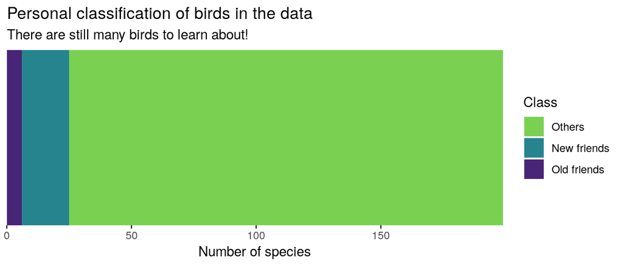

```r
ggplot(bird_counts %>% filter(year %in% "1921"), aes("", fill = Class)) +
    geom_bar() +
    coord_flip() +
    scale_fill_viridis_d(begin = 0.1, end = 0.8, direction =  -1) +
    labs(x = NULL, y = "Number of species", title = "Personal classification of birds in the data",
         subtitle = "There are still many birds to learn about!") +
    scale_x_discrete(expand = c(0, 0), breaks = NULL) +
    scale_y_continuous(expand = c(0, 0 ))
```

I still don’t know most of the birds spotted in Hamilton at Christmas!

## Summarize data per bird

Are birds I know common? (must be)

```r
summary_birds <- bird_counts %>%
    group_by(species, species_latin, Class) %>%
    summarize(
        mean_counted_by_hour = mean(how_many_counted_by_hour, na.rm = TRUE),
        variance_counted_by_hour = var(how_many_counted_by_hour, na.rm = TRUE),
        years_spotted = sum(how_many_counted > 0)) %>%
    mutate(
        Regularity = case_when(years_spotted < 5 ~ "Rare",
                               years_spotted < 94/2 ~ "Less than half of the years",
                               years_spotted < 95-5 ~ "More than half of the years",
                               years_spotted > 94-5 ~ "Very common")
    )
```

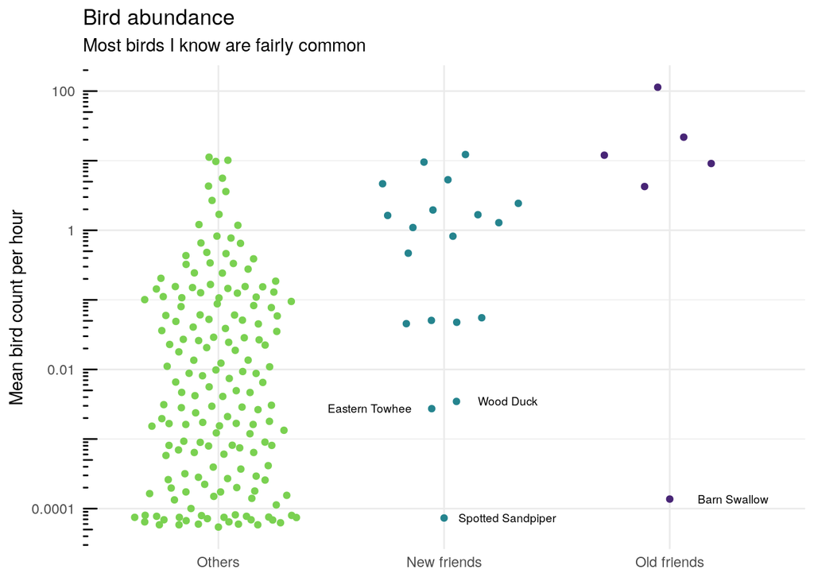

```r
ggplot(summary_birds %>% filter(mean_counted_by_hour > 0), aes(Class, mean_counted_by_hour)) +
    geom_quasirandom(aes(colour = Class), show.legend = FALSE, na.rm = TRUE) +
    geom_text(data = summary_birds %>% filter(species %in% c("Wood Duck", "Spotted Sandpiper", "Barn Swallow")),
              aes(label = species), size = 2.5, nudge_x = 0.28) +
    geom_text(data = summary_birds %>% filter(species %in% c("Eastern Towhee")),
              aes(label = species), size = 2.5, nudge_x = -0.33) +
    scale_y_log10(breaks = c(0.0001, 0.01, 1, 100),
                  labels = c("0.0001", "0.01", "1", "100")) +
    annotation_logticks(sides = "l") +
    scale_colour_viridis_d(begin = 0.1, end = 0.8, direction =  -1) +
    labs(x = NULL, y = "Mean bird count per hour", title = "Bird abundance",
         subtitle = "Most birds I know are fairly common") +
    theme_minimal()
```

## Look at abundance temporal trends (of friends)

```r
# Impute number of hours in years that have NAs (several years between 1921 and 1950)
# I'm going to use Downy Woodpecker as reference, because it's spotter every year at a similar rate
downys_per_hour_1929_1950 <- bird_counts %>%
    filter(species %in% "Downy Woodpecker" & year <= 1950) %>%
    pull(how_many_counted_by_hour) %>%
    mean(na.rm = TRUE)

bird_counts_imputed <- bird_counts %>%
    group_by(year) %>%
    # Use Downy woodpecker to estimate total_hours
    mutate(total_hours = if_else(
        is.na(total_hours),
        round(how_many_counted[species %in% "Downy Woodpecker"] / downys_per_hour_1929_1950),
        total_hours)) %>%
    # Fill counts/h those years
    mutate(how_many_counted_by_hour = if_else(
        is.na(how_many_counted_by_hour),
        how_many_counted/total_hours,
        how_many_counted_by_hour))

# Order by mean abundance
bird_order <- summary_birds %>%
    arrange(mean_counted_by_hour) %>%
    pull(species)
bird_counts_imputed <- bird_counts_imputed %>%
    mutate(species = factor(species, levels = bird_order))
```

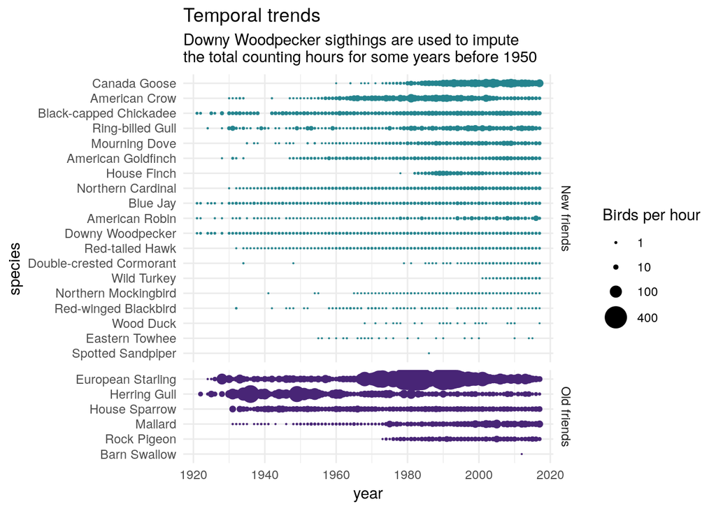

```r
ggplot(bird_counts_imputed %>%
           filter(Class %in% c("New friends", "Old friends") & how_many_counted_by_hour),
       aes(year, species, size = how_many_counted_by_hour, colour = Class)) +
    geom_point(show.legend = c(colour = FALSE)) +
    scale_size_area(max_size = 7, breaks = c(1, 10, 100, 400), name = "Birds per hour") +
    scale_colour_viridis_d(begin = 0.1, end = 0.8, direction =  -1, drop = FALSE) +
    scale_x_continuous(expand = c(0.04, 0)) +
    facet_grid(rows = vars(Class), scales = "free", space ="free") +
    theme_minimal() +
    labs(title = "Temporal trends",
         subtitle = "Downy Woodpecker sigthings are used to impute\nthe total counting hours for some years before 1950")
```